# Project: Impact of ART on Weathering

## Data Information

**Outcomes:** **Allostatic Load**, named *AL_75_mix* and is a function of:

- IL6 (75th percentile),
- epinephrine (75th percentile),
- norepinephrine (75th perc.),
- cortisol (75th perc.),
- hsCRP (JNC7),
- diastolic blood pressure (JNC7),
- systolic blood pressure (JNC7),
- HDL (ATPIII),
- LDL (ATPIII),
- waist (ATPIII),
- glucose (Expert Committee on Diagnosis and Classification of Diabetes Mellitus),
- HBA1C (Expert Committee on Diagnosis and Classification of Diabetes Mellitus),
- cholesterol (ATPIII)
- triglycerides (ATPIII)
- BMI (standards)

**Binary Allostatic Load**, named *AL_75_dichot* is a binary version that sets (AL_75_mix < 6) = 0 and (AL_75_mix >= 6) = 1

**Telomere length** (n = 140) named tlr. Has been completely merged with data

**Predictor:** **Anticipatory Racism Threat** *aRT*

Reliability of the subscales:

```r
############################
# Code for imputing data
############################
library(readxl)
library(tidyr)
library(dplyr)
library(mice)

# The data with POV includes all of the multiple imputations from the SWS analysis,
# we'll extract just the original dataset for this work
dta_with_pov <- dta_with_pov[dta_with_pov$"_mi_m" == 0,]

# Extracting data for imputation
dta_impute <- dta_with_pov %>%
  dplyr::select(
    Subject_Number,
    # variables for imputation
    art75, art78, art63, art60, art74, art73, art15, art16, art14, art17,
    art21, art82, art52, art51, art43, eds1, eds2, eds3, eds4, eds5, eds6,
    eds7, eds8, eds9, eds10, eod1, eod2, eod3, eod4, eod5, eod6, eod7, eod8,
    ln_il6, ln_tnfa, ln_hscrp, ln_epinephrine, ln_norepi, ln_cortisol, total_chol,
    ln_hdl, ldl_dir, ln_triglyc, ln_hba1c, ln_systolbp, ln_diastolbp, waist, hip, bmi,
    nonhdl_chol, neurot_avg, neurot1, neurot2, neurot3, neurot4, neurot5, neurot6, neurot7, neurot8,
    # variables not for imputation
    educ_dichot, employ_dichot, age_yrs, marstatus_dichot, hlth_ins,
    cvmeds_ever, cvmeds_current, diabetesmedtx_ever, diabetesmedtx_current,
    smoke_now, exercise_week, drinksperday, RBRS_score, think_race, antic_vig,
    JH_sum, FNE_sum, pov)

# Recoding categorical variables so that one of the outcomes is 0 for imputation model
dta_impute <- dta_impute %>%
  # subtract 1 from each current value
  mutate_at(vars(starts_with("art")), ~.-1) %>%
  mutate_at(vars(starts_with("eds")), ~.-1) %>%
  mutate_at(vars(starts_with("eod")), ~.-1) %>%
  # Turn categorical variables from numeric to categorical
  mutate_at(vars(art75:eod8), factor) %>%
  # Replace 88 with NA (which only appears in drinksperday in this dataset, which we won't impute)
  mutate(drinksperday = ifelse(drinksperday == 88, NA, drinksperday))

# Setting up the imputation
imp <- mice(dta_impute,
            maxit = 0,
            print = FALSE)

# Removing the i.hlth_ins from predicting the aRT, eds, eod variables
# Removing Subject_Number from all
# "Setting all entries within the variable column to zero effectively removes it from the predictor set"
imp_pred <- imp$predictorMatrix
imp_pred[substr(rownames(imp_pred),1,3) =="art", colnames(imp_pred) == "hlth_ins"] <- 0
imp_pred[substr(rownames(imp_pred),1,3) =="eod", colnames(imp_pred) == "hlth_ins"] <- 0
imp_pred[substr(rownames(imp_pred),1,3) =="eds", colnames(imp_pred) == "hlth_ins"] <- 0
imp_pred[, colnames(imp_pred) == "Subject_Number"] <- 0

# Skipping imputation
imp_where <- dta_impute %>%
  # Setting up a data frame with logicals where TRUE == impute, and FALSE = don't impute
  mutate_at(vars(art75:neurot8), ~ TRUE) %>%
  mutate_at(vars(Subject_Number,educ_dichot:pov), ~ FALSE)

# Checking method of imputation
imp_method <- imp$method
imp_method

# Check that polyreg is chosen for all categorical
all(imp_method[substr(rownames(imp_method), 1,3) == "art"] == "polyreg")
all(imp_method[substr(rownames(imp_method), 1,3) == "eds"] == "polyreg")
all(imp_method[substr(rownames(imp_method), 1,3) == "eod"] == "polyreg")

# Check that pmm is chosen for all others
table(imp_method)

dta_impute_final <- mice(
  data = dta_impute,
  m = 20,
  method = imp_method,
  predictorMatrix = imp_pred,
  where = imp_where,
  maxit = 5,
  seed = 66752)
```

```r
# Variable recoding
############
library(readxl)
library(tidyverse)
library(mice)
load("2020-12-17_imputed-aawhhs-data-v3.RData")
library(haven)
dta_with_pov <- read_dta("Recodeddata_040516_207obs_FINAL_nomeduse.dta")
dta_with_pov <- dta_with_pov[dta_with_pov$"_mi_m" == 0,] # extracting only the original data
#dta_long <- mice::complete(dta_long, action = "long", include = TRUE)

# For all covariates, the lowest number is the most privileged group, except pov.

#For drinksperday: NA=skipped due to answering "no" on a prior question.
# Therefore, NAs should be recoded to no
dta_long <- dta_long %>%
  mutate(drinksperday = ifelse(is.na(drinksperday), 0, drinksperday))

# For analysis use drinksperday (not alcohfreq_yr) as the covariate.
# Standards show that for women of all ages up to 1 drink per day can have health benefits.
# This is considered moderate use. Anything more than that is considered a health risk.
# RE: DRINKS PER DAY. THE QUESTION ASKS ON A TYPICAL DAY WHEN YOU DRANK, HOW MANY DRINKS DID YOU HAVE.
# THEREFORE, IT SHOULD BE CODED 0 FOR <=3 DRINKS AND 1 FOR >3 DRINKS. THIS IS CONSISTENT WITH STANDARDS
# INDICATING THAT >3 DRINKS ON ANY GIVEN DAY IS CONSIDERED HEAVY DRINKING.
# BUT FORDRINKSPERDAY 1=1, 2=1-2, 3=3-4, 4=5-6 AND SO ON. SO CAN'T CUT IT EXACTLY AT 3.
#  THEREFORE, CODE AS 0 FOR 1 AND 2 AND CODE 1 FOR >=3.
dta_long <- dta_long %>%
  mutate(alcohuse = ifelse(drinksperday <= 2, 0, 1))

# This var is messed up because the high numbers (highest is 45) don't make sense based on the question
# (categories 0-7). Since the standard is 30 min at least 5 days per week, could cut it at 0=>=5 & 1=<5.
# For exercise, 0=healthy and 1=not healthy based on current standards of exercising a minimum of 5 times
# per week for 30 minutes.
dta_long <- dta_long %>%
  mutate(exercise = ifelse(exercise_week >= 5 & exercise_week <= 45, 0, 1))

# Recode EDS and aRT vars, calculate sum scores
dta_long <- dta_long %>%
  mutate_at(vars(starts_with("art"),
                 starts_with("eds"),
                 starts_with("eod")), ~as.numeric(.)) %>%  # using as.numeric automatically sets value to the level (e.g. "0" becomes 1)
  # Compared to YouGov, the art conf. concern and stereo. aware. are reverse coded. Going to replace (1 = 5) etc
  mutate_at(vars(art75, art78, art63, art60, art74, art73, art75, art78, art63, art60, art74, art73), ~6-.) %>%
  # EDS also needs to be reversed (1 = 6) etc.
  mutate_at(vars(starts_with("eds")), ~7-.) %>%
  rowwise() %>%
  mutate(
    # aRT
    art_confirmation_concern = sum(c(art75, art78, art63, art60, art74, art73)), # high scores, high concern
    art_stereotype_awareness = sum(c(art15, art16, art14, art17, art21)), # high scores, high awareness
    art_resilience = sum(c(art82, art52, art51, art43)), # high scores, low resilience
    # EDS
    eds_sum = sum(c(eds1, eds2, eds3, eds4, eds5, eds6, eds7, eds8, eds9, eds10)),
    eds_avg = mean(c(eds1, eds2, eds3, eds4, eds5, eds6, eds7, eds8, eds9, eds10)),
    eds_cat = case_when(eds_sum <= 20 ~ 0,
                        eds_sum > 20 & eds_sum <= 30 ~ 1,
                        eds_sum > 30 & eds_sum <= 40 ~ 2,
                        eds_sum > 40 & eds_sum <= 50 ~ 3,
                        eds_sum > 50 & eds_sum <= 60 ~ 4),
    eds_cat2 = case_when(eds_sum <= 20 ~ 0,
                         eds_sum > 20 & eds_sum <= 30 ~ 1,
                         eds_sum > 30 & eds_sum <= 40 ~ 2,
                         eds_sum > 40 & eds_sum <= 60 ~ 3),
    # EOD
    eod_sum = sum(c(eod1, eod2, eod3, eod4, eod5, eod6, eod7, eod8)),
    eod_avg = mean(c(eod1, eod2, eod3, eod4, eod5, eod6, eod7, eod8)))

# Checking reliability of aRT scale items
cc <- dta_long %>% filter(.imp == 0) %>% select(art15, art16, art14, art17, art21)
res <- dta_long %>% filter(.imp == 0) %>% select(art82, art52, art51, art43)
sa <- dta_long %>% filter(.imp == 0) %>% select(art75, art78, art63, art60, art74, art73)
psych::alpha(res) # alpha = 0.66 (0.59, 0.74) <- not great
psych::alpha(cc) # alpha = 0.94 (0.93, 0.95)
psych::alpha(sa) # alpha = 0.86 (0.83, 0.89)

##################################
# Allostatic load and biomarkers
###################################
# Merging back with additional variables that weren't used for imputation
# but are needed for allostatic load, etc.
dta_add_vars <- dta_with_pov %>%
  dplyr::select_at(vars(Subject_Number,
                        starts_with("glucose"),
                        ldl_dichot)) # need ldl_c to estimate this from imputed data

dta_long <- full_join(dta_long,
                      dta_add_vars,
                      by = "Subject_Number")

dta_long <- dta_long %>%
  rowwise() %>%
  # Back transform from logged
  mutate(p_il6 = exp(ln_il6),
         p_tnfa = exp(ln_tnfa),
         p_hscrp = exp(ln_hscrp),
         p_epinephrine = exp(ln_epinephrine),
         p_norepi = exp(ln_norepi),
         p_cortisol = exp(ln_cortisol),
         p_hdl = exp(ln_hdl),
         p_triglyc = exp(ln_triglyc),
         p_hba1c = exp(ln_hba1c),
         p_systolbp = exp(ln_systolbp),
         p_diastolbp = exp(ln_diastolbp)) %>%
  mutate(
    # hsCRP
    # *AHA guidelines for hsCRP
    # <1=low risk, 1-3=average risk, >3=high risk.
    hscrp_cat = case_when(p_hscrp < 1 ~ 0,
                          p_hscrp >= 1 & p_hscrp <= 3 ~ 1,
                          p_hscrp > 3 & p_hscrp <= 40 ~ 2),
    hscrp_dichot = case_when(p_hscrp <= 3 ~ 0,
                             p_hscrp > 3 & p_hscrp <= 40 ~ 1),
    # blood pressure
    diastolbp_cat_jnc7 = case_when(p_diastolbp < 80 ~ 0,
                                   p_diastolbp >= 80 & p_diastolbp < 90 ~ 1,
                                   p_diastolbp >= 90 & p_diastolbp <= 151 ~ 2),
    systolbp_cat_jnc7 = case_when(p_systolbp < 120 ~ 0,
                                  p_systolbp >= 120 & p_systolbp < 140 ~ 1,
                                  p_systolbp >= 140 & p_systolbp <= 194 ~ 2),
    #JNC8 says <90 for clinical target for not at risk. We are following the JNC7 guidelines that indicate pre-hypertension -- so disease process already started. Challenge is, if these people not really at risk, could bias results towards the null. So will create a second variable using JNC8.
    diastolbp_dichot_jnc7 = ifelse(p_diastolbp < 80, 0, 1),
    diastolbp_dichot_jnc8 = ifelse(p_diastolbp < 90, 0, 1),
    systolbp_dichot_jnc7 = ifelse(p_diastolbp < 120, 0, 1),
    systolbp_dichot_jnc8 = ifelse(p_diastolbp < 140, 0, 1),
    # HDL guidelines from ATPIII
    hdl_dichot = ifelse(p_hdl >= 50 & p_hdl <= 152, 0, 1),
    hdl_dichot_90 = ifelse(p_hdl >= 40 & p_hdl <= 152, 0, 1),
    # ATPIII measures high-risk for women is <50 and men <40. Low risk is measured at >=60 in general.
    # hdl is coded such that higher levels of hdl are better for health and lower numbers are worse for
    # health. Therefore 0-2 goes in order of increaseing risk with 2 representing the lowest hdl numbers,
    # and correspondingly the highest level of risk.
    hdl_cat = case_when(p_hdl >= 50 & p_hdl < 153 ~ 0,
                        p_hdl >= 40 & p_hdl < 50 ~ 1,
                        p_hdl < 40 ~ 2),
    # TG guidelines use ATPIII
    triglyc_dichot = ifelse(p_triglyc < 150, 0, 1),
    triglyc_dichot_90 = ifelse(p_triglyc < 200, 0, 1),
    triglyc_cat = case_when(p_triglyc < 150 ~ 0,
                            p_triglyc >= 150 & p_triglyc < 200 ~ 1,
                            p_triglyc >= 200 & p_triglyc <= 499 ~ 2), # *official risk categories for triglycerides has one additional level of risk (>=500), but we had no values this high.
    # ATPIII guidelines
    waist_dichot = ifelse(waist <= 35, 0, 1), #ATPIII guidelines
    waisthip = waist/hip,
    waisthip_dichot = ifelse(waisthip <= 0.85, 0, 1), #*WHO guidelines ATPIII doesn't have a guidelne for waist/hip.
    # AIC guidelines based on Expert Committee on Diagnosis and Classification of Diabetes Mellitus (standards of med care in diabetes, 2011)
    hba1c_dichot = ifelse(p_hba1c < 5.7, 0, 1),
    hba1c_dichot_90 = ifelse(p_hba1c < 6.5, 0, 1),
    hba1c_cat = case_when(p_hba1c < 5.7 ~ 0,
                          p_hba1c >= 5.7 & p_hba1c < 6.5 ~ 1,
                          p_hba1c >= 6.5 & p_hba1c < 11.5 ~ 2),
    # il6
    il6_75 = ifelse(p_il6 > 7.85 & p_il6 < 63, 1, 0),
    il6_90 = ifelse(p_il6 > 17.8 & p_il6 < 63, 1, 0),
    # TNFA
    tnfa_75 = ifelse(p_tnfa > 48.20 & p_tnfa < 1157, 1, 0),
    tnfa_90 = ifelse(p_tnfa > 138.50 & p_tnfa < 1157, 1, 0),
    # hsCRP
    hscrp_75 = ifelse(p_hscrp <= 6.77, 0, 1),
    hscrp_90 = ifelse(p_hscrp <= 9.64, 0, 1),
    # Epinephrine
    epi_75 = ifelse(p_epinephrine <= 77.70, 0, 1),
    epi_90 = ifelse(p_epinephrine <= 120, 0, 1),
    # Norepi
    norepi_75 = ifelse(p_norepi <= 686.30, 0, 1),
    norepi_90 = ifelse(p_norepi <= 848.95, 0, 1),
    # Cortisol
    cort_75 = ifelse(p_cortisol <= 12.69, 0, 1),
    cort_90 = ifelse(p_cortisol <= 17.32, 0, 1),
    # Diastolbp
    diastolbp_75 = ifelse(p_diastolbp <= 90.25, 0, 1),
    diastolbp_90 = ifelse(p_diastolbp <= 98.70, 0, 1),
    # Systolbp
    systolbp_75 = ifelse(p_systolbp <= 131.30, 0, 1),
    systolbp_90 = ifelse(p_systolbp <= 146.55, 0, 1),
    # HDL
    hdl_25 = ifelse(p_hdl < 44.6, 1, 0),
    hdl_10 = ifelse(p_hdl < 37.05, 1, 0),
    # LDL - already exists
    # Triglyc
    triglyc_75 = ifelse(p_triglyc <= 95.30, 1, 0),
    triglyc_90 = ifelse(p_triglyc <= 134.95, 1, 0),
    # Chol
    chol_dichot = ifelse(total_chol < 160, 0, 1),
    # Glucose
    # <100 is normal fasting glucose, 100-125 impaired fasting glucose, >=126 is high risk.
    # This is based on Expert Committee on Diagnosis and Classification of Diabetes Mellitus
    # (standards of med care in diabetes, 2011). They indicate that some use a cut-off of 110 rather
    # than 100. ATPIII says 110.
    glucose_dichot = ifelse(glucose >= 70 & glucose < 100, 0, 1),
    # BMI
    bmi_dichot = ifelse(bmi >= 18.5 & bmi < 25, 0, 1)
    # etc.. We have everything we need to do the mixed Allostatic load calculation
    )

# AL_75_mix based on mix of clinical and non-clinical cut-points.
dta_long <- dta_long %>%
  mutate(AL_75_mix = sum(c(il6_75,epi_75,
                           norepi_75,cort_75,
                           hscrp_dichot,diastolbp_dichot_jnc7,
                           systolbp_dichot_jnc7,hdl_dichot,
                           ldl_dichot,waist_dichot,
                           glucose_dichot,hba1c_dichot,
                           chol_dichot,triglyc_dichot,
                           bmi_dichot))) %>%
  mutate(AL_75_dichot = ifelse(AL_75_mix < 6, 0, 1))


# Incorporate telomere length data
telo_dta <- read_excel("../allen-lab/AAWHHS-aRT-work/AAWHHS_TLR_data_for_merge.xlsx")

dta_long <-
  full_join(dta_long, telo_dta, by = "Subject_Number")

save(dta_long,
     file = "../allen-lab/AAWHHS-aRT-work/2020-12-17_imputed-aawhhs-data-v3.RData")
```

```r
load("2020-12-17_imputed-aawhhs-data-v3.RData")
# Checking reliability of aRT scale items
cc <- dta_long %>% filter(.imp == 0) %>% select(art15, art16, art14, art17, art21)
res <- dta_long %>% filter(.imp == 0) %>% select(art82, art52, art51, art43)
sa <- dta_long %>% filter(.imp == 0) %>% select(art75, art78, art63, art60, art74, art73)
```

Alpha for Res Subscale

|  | raw_alpha | std.alpha | G6(smc) | average_r | S/N | ase | mean | sd | median_r |
| --- | --- | --- | --- | --- | --- | --- | --- | --- | --- |
|  | 0.6584356 | 0.6566215 | 0.6053745 | 0.3234373 | 1.912238 | 0.0385642 | 2.747537 | 0.8555982 | 0.3308264 |

Alpha for cc Subscale

|  | raw_alpha | std.alpha | G6(smc) | average_r | S/N | ase | mean | sd | median_r |
| --- | --- | --- | --- | --- | --- | --- | --- | --- | --- |
|  | 0.9391846 | 0.9387243 | 0.932672 | 0.7539331 | 15.31968 | 0.0067331 | 2.525123 | 1.223009 | 0.7924191 |

Alpha for sa subscale

|  | raw_alpha | std.alpha | G6(smc) | average_r | S/N | ase | mean | sd | median_r |
| --- | --- | --- | --- | --- | --- | --- | --- | --- | --- |
|  | 0.857871 | 0.8569055 | 0.8487726 | 0.4995157 | 5.988389 | 0.0152709 | 2.960591 | 0.9739914 | 0.5201683 |

## Path Analysis: Allostatic Load

```r
library(misty)
library(mice)
library(semTools)
# adjusting variables per Yije's code
dta_long$eod_sum <- dta_long$eod_sum/4
dta_long$res <- dta_long$art_resilience/5
dta_long$cc <- dta_long$art_confirmation_concern/5
dta_long$sa <- dta_long$art_stereotype_awareness/5

# centering variables per Yije's code
dta_long$eod_sum <- center(dta_long$eod_sum, type = "CWC", group = dta_long$.imp)
dta_long$res <- center(dta_long$res,  type = "CWC", group = dta_long$.imp)
dta_long$cc <- center(dta_long$cc, type = "CWC", group = dta_long$.imp)
dta_long$sa <- center(dta_long$sa, type = "CWC", group = dta_long$.imp)
dta_long$cvmeds_current <- center(dta_long$cvmeds_current, type = "CWC", group = dta_long$.imp)
dta_long$diabetesmedtx_current <- center(dta_long$diabetesmedtx_current, type = "CWC", group = dta_long$.imp)
dta_long$educ_dichot <- center(dta_long$educ_dichot, type = "CWC", group = dta_long$.imp)
dta_long$pov <- center(dta_long$pov, type = "CWC", group = dta_long$.imp)
dta_long$age_yrs <- center(dta_long$age_yrs, type = "CWC", group = dta_long$.imp)
# creating interactions
dta_long$int_res <- dta_long$res * dta_long$eod_sum
dta_long$int_cc <- dta_long$cc * dta_long$eod_sum
dta_long$int_sa <- dta_long$sa * dta_long$eod_sum

dta_long$eod_sum2 <- dta_long$eod_sum * dta_long$eod_sum
dta_long$int_res2 <- dta_long$res * dta_long$eod_sum2
dta_long$int_cc2 <- dta_long$cc * dta_long$eod_sum2
dta_long$int_sa2 <- dta_long$sa * dta_long$eod_sum2

dta_long <- dta_long[dta_long$.id != 184, ] #removing outlier
```

```r
dta_mids <- as.mids(dta_long, .imp = ".imp", .id = ".id")

mice.imp <- NULL
for(i in 1:20) {
  mice.imp[[i]] <- mice::complete(dta_mids, action = i, inc=FALSE)  }
```

## Path Analysis: Allostatic Load

Running both linear and quadratic terms (per the previous paper)

```r
model <- '
# measurement model
AL_75_mix ~ eod_sum
AL_75_mix ~ eod_sum2
AL_75_mix ~ res + sa +  cc
AL_75_mix ~ int_res2 +  int_sa2 +  int_cc2
AL_75_mix ~ int_res +  int_sa +  int_cc
#!covariates;
AL_75_mix ~ cvmeds_current + diabetesmedtx_current + educ_dichot + pov + age_yrs
cc ~~ res
'

out3 <- runMI(model,
              data=mice.imp,
              fun="sem",
              meanstructure = TRUE)
summary(out3)
```

```
## lavaan.mi object based on 20 imputed data sets.
## See class?lavaan.mi help page for available methods.
##
## Convergence information:
## The model converged on 20 imputed data sets
##
## Rubin's (1987) rules were used to pool point and SE estimates across 20 imputed data sets, and to calculate degrees of freedom for each parameter's t test and CI.
```

```
##
## Parameter Estimates:
##
##   Standard errors                             Standard
##   Information                                 Expected
##   Information saturated (h1) model            Expected
##   Standard errors                           Structured
##   Information                               Structured
##
## Regressions:
##                    Estimate  Std.Err  t-value       df  P(>|t|)
##   AL_75_mix ~
##     eod_sum          -0.009    0.082   -0.107      Inf    0.915
##     eod_sum2         -0.039    0.033   -1.174 5735.612    0.241
##     res               0.143    0.212    0.676 9115.229    0.499
##     sa               -0.360    0.160   -2.256      Inf    0.024
##     cc               -0.317    0.120   -2.638 3278.753    0.008
##     int_res2          0.013    0.028    0.451 5480.981    0.652
##     int_sa2           0.042    0.020    2.111      Inf    0.035
##     int_cc2           0.034    0.018    1.933 2095.086    0.053
##     int_res          -0.124    0.107   -1.163 5346.213    0.245
##     int_sa           -0.049    0.062   -0.777      Inf    0.437
##     int_cc           -0.002    0.060   -0.034      Inf    0.973
##     cvmeds_current    0.874    0.373    2.342      Inf    0.019
##     dbtsmdtx_crrnt    1.775    0.722    2.458 8301.245    0.014
##     educ_dichot       1.249    0.320    3.898      Inf    0.000
##     pov               0.496    0.370    1.341      Inf    0.180
##     age_yrs           0.062    0.026    2.375      Inf    0.018
##
## Covariances:
##                            Estimate  Std.Err  t-value       df  P(>|t|)
##   res ~~
##     cc                        0.107    0.065    1.660      Inf    0.097
##   eod_sum ~~
##     eod_sum2                  6.968    1.260    5.531      Inf    0.000
##     sa                       -0.450    0.229   -1.968      Inf    0.049
##     int_res2                  9.270    1.714    5.409      Inf    0.000
##     int_sa2                  -4.910    2.143   -2.291 6930.664    0.022
##     int_cc2                  10.304    2.157    4.777 5660.996    0.000
##     int_res                   1.328    0.367    3.619 8770.276    0.000
```

[output cut: 122 more lines]

```
##     cc                1.389    0.160    8.696      Inf    0.000
##     eod_sum           5.066    0.583    8.695      Inf    0.000
##     eod_sum2         37.780    4.346    8.694      Inf    0.000
##     sa                1.522    0.175    8.696      Inf    0.000
##     int_res2         70.700    8.134    8.692 4107.855    0.000
##     int_sa2         132.233   15.209    8.694      Inf    0.000
##     int_cc2         117.887   13.560    8.694      Inf    0.000
##     int_res           3.668    0.422    8.693 8224.181    0.000
##     int_sa            8.447    0.971    8.695      Inf    0.000
##     int_cc            7.914    0.910    8.694      Inf    0.000
##     cvmeds_current    0.155    0.018    8.696      Inf    0.000
##     dbtsmdtx_crrnt    0.043    0.005    8.696      Inf    0.000
##     educ_dichot       0.212    0.024    8.696      Inf    0.000
##     pov               0.162    0.019    8.696      Inf    0.000
##     age_yrs          34.665    3.986    8.696      Inf    0.000
```

```r
lavTestLRT.mi(out3, test = "D2", pool.robust = TRUE)
```

```
##         F       df1       df2    pvalue      ariv       fmi      npar    ntotal
##    10.923    28.000 18614.946     0.000     0.026     0.025   142.000   157.000
```

```r
fitMeasures(out3, fit.measures = c("rmsea","srmr","cfi"),
            test = "D2", pool.robust = TRUE)
```

```
##                 cfi               rmsea      rmsea.ci.lower      rmsea.ci.upper
##               0.103               0.251               0.226               0.277
##        rmsea.pvalue                srmr        srmr_bentler srmr_bentler_nomean
##               0.000               0.100               0.100               0.105
##          srmr_mplus   srmr_mplus_nomean
##               0.100               0.105
```

Quadratic relationship comes out for AL.

## Path Analysis: Telomere Length

Running both linear and quadratic terms (per the previous paper)

```r
model <- '
# measurement model
tlr ~ eod_sum2
tlr ~ eod_sum
tlr ~ res + sa +  cc
tlr ~ int_res +  int_sa +  int_cc
tlr ~ int_res2 +  int_sa2+  int_cc2
#!covariates;
tlr ~ cvmeds_current + diabetesmedtx_current + educ_dichot + pov + age_yrs
cc ~~ sa
'

out4 <- runMI(model,
              data=mice.imp,
              fun="sem",
              meanstructure = TRUE)
summary(out4)
```

```
## lavaan.mi object based on 20 imputed data sets.
## See class?lavaan.mi help page for available methods.
##
## Convergence information:
## The model converged on 20 imputed data sets
##
## Rubin's (1987) rules were used to pool point and SE estimates across 20 imputed data sets, and to calculate degrees of freedom for each parameter's t test and CI.
```

```
##
## Parameter Estimates:
##
##   Standard errors                             Standard
##   Information                                 Expected
##   Information saturated (h1) model            Expected
##   Standard errors                           Structured
##   Information                               Structured
##
## Regressions:
##                    Estimate  Std.Err  t-value       df  P(>|t|)
##   tlr ~
##     eod_sum2         -0.009    0.006   -1.375      Inf    0.169
##     eod_sum           0.023    0.015    1.569      Inf    0.117
##     res              -0.064    0.060   -1.063      Inf    0.288
##     sa               -0.036    0.020   -1.763      Inf    0.078
##     cc                0.003    0.023    0.123      Inf    0.902
##     int_res          -0.024    0.021   -1.160      Inf    0.246
##     int_sa           -0.029    0.011   -2.671      Inf    0.008
##     int_cc           -0.001    0.012   -0.103      Inf    0.918
##     int_res2          0.010    0.008    1.210      Inf    0.226
##     int_sa2           0.002    0.003    0.640      Inf    0.522
##     int_cc2          -0.004    0.004   -1.028      Inf    0.304
##     cvmeds_current    0.042    0.071    0.591      Inf    0.554
##     dbtsmdtx_crrnt    0.168    0.137    1.231      Inf    0.218
##     educ_dichot       0.029    0.057    0.518      Inf    0.604
##     pov               0.134    0.069    1.935      Inf    0.053
##     age_yrs           0.005    0.005    0.925      Inf    0.355
##
## Covariances:
##                            Estimate  Std.Err  t-value       df  P(>|t|)
##   sa ~~
##     cc                       -0.151    0.123   -1.230      Inf    0.219
##   eod_sum2 ~~
##     eod_sum                   4.782    1.066    4.486      Inf    0.000
##     res                       0.834    0.314    2.658      Inf    0.008
##     int_res                   4.431    0.881    5.030      Inf    0.000
##     int_sa                   -2.081    1.281   -1.625      Inf    0.104
##     int_cc                    4.816    1.267    3.801      Inf    0.000
##     int_res2                 22.357    3.796    5.890      Inf    0.000
```

[output cut: 122 more lines]

```
##     cc                1.272    0.154    8.284      Inf    0.000
##     eod_sum2         29.256    3.532    8.283      Inf    0.000
##     eod_sum           4.548    0.549    8.284      Inf    0.000
##     res               0.438    0.053    8.284      Inf    0.000
##     int_res           2.969    0.358    8.284      Inf    0.000
##     int_sa            7.545    0.911    8.284      Inf    0.000
##     int_cc            6.736    0.813    8.283      Inf    0.000
##     int_res2         50.495    6.096    8.284      Inf    0.000
##     int_sa2         100.273   12.106    8.283      Inf    0.000
##     int_cc2          96.313   11.627    8.283      Inf    0.000
##     cvmeds_current    0.162    0.020    8.284      Inf    0.000
##     dbtsmdtx_crrnt    0.042    0.005    8.284      Inf    0.000
##     educ_dichot       0.225    0.027    8.284      Inf    0.000
##     pov               0.162    0.020    8.284      Inf    0.000
##     age_yrs          34.601    4.177    8.284      Inf    0.000
```

```r
lavTestLRT.mi(out4, test = "D2", pool.robust = TRUE)
```

```
##         F       df1       df2    pvalue      ariv       fmi      npar    ntotal
##     8.293    28.000 44557.947     0.000     0.016     0.016   142.000   138.000
```

```r
fitMeasures(out4, fit.measures = c("rmsea","cfi"),
            test = "D2", pool.robust = TRUE)
```

```
##            cfi          rmsea rmsea.ci.lower rmsea.ci.upper   rmsea.pvalue
##          0.025          0.230          0.203          0.258          0.000
```

Linear Relationship comes up for Telomere length.

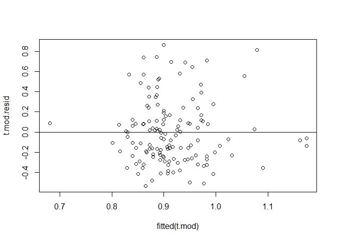

```r
t.mod <- lm(tlr ~ eod_sum*sa, mice.imp[[1]])
t.mod.resid <- resid(t.mod)
#produce residual vs. fitted plot
plot(fitted(t.mod), t.mod.resid)
#add a horizontal line at 0
abline(0,0)
```

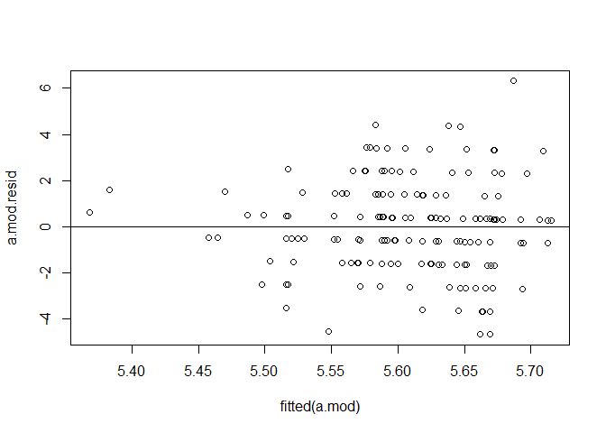

```r
a.mod <- lm(AL_75_mix ~ eod_sum*sa, mice.imp[[1]])
a.mod.resid <- resid(a.mod)
#produce residual vs. fitted plot
plot(fitted(a.mod), a.mod.resid)
#add a horizontal line at 0
abline(0,0)
```

As expected from the SEM output, the relationship with telomere length seems to be best fit linearly while the relationship with AL seems to be best fit as a quadratic relationship.

## Plotting ART SA * EOD Interaction on Telomere Length

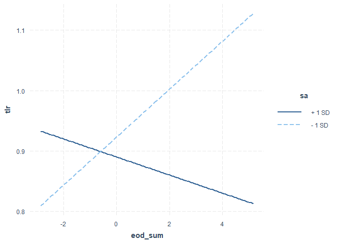

```r
library(interactions)

fiti  <- lm( tlr ~ eod_sum * sa, mice.imp[[1]])

interact_plot(fiti, pred = eod_sum, modx = sa, modx.values = "plus-minus")
```